# UN Exploration using Tidyverse

```r
library('tidyverse')
```

1. Using the read_csv() function, read the GDP dataset into your notebook as a tibble called gdp_df. After reading it in, inspect the first 10 rows and then inspect the last 10 rows.

```r
gdp_df <- read_csv('../data/gdp_per_capita.csv', show_col_types = FALSE)
```

```r
gdp_df |>
  head(10)
```

| Country or Area | Year | Value | Value Footnotes |
| --- | --- | --- | --- |
| Afghanistan | 2020 | 1970.560 | NA |
| Afghanistan | 2019 | 2065.036 | NA |
| Afghanistan | 2018 | 2033.804 | NA |
| Afghanistan | 2017 | 2058.400 | NA |
| Afghanistan | 2016 | 2057.068 | NA |
| Afghanistan | 2015 | 2068.266 | NA |
| Afghanistan | 2014 | 2102.385 | NA |
| Afghanistan | 2013 | 2116.465 | NA |
| Afghanistan | 2012 | 2075.492 | NA |
| Afghanistan | 2011 | 1904.560 | NA |

```r
gdp_df |>
  tail(10)
```

| Country or Area | Year | Value | Value Footnotes |
| --- | --- | --- | --- |
| Zimbabwe | 1999 | 2872.715 | NA |
| Zimbabwe | 1998 | 2915.053 | NA |
| Zimbabwe | 1997 | 2856.118 | NA |
| Zimbabwe | 1996 | 2808.559 | NA |
| Zimbabwe | 1995 | 2573.994 | NA |
| Zimbabwe | 1994 | 2603.927 | NA |
| Zimbabwe | 1993 | 2420.093 | NA |
| Zimbabwe | 1992 | 2437.153 | NA |
| Zimbabwe | 1991 | 2733.697 | NA |
| Zimbabwe | 1990 | 2652.129 | NA |

2. Drop the ‘Value Footnotes’ column, and rename the remaining columns to ‘Country’, ‘Year’, and ‘GDP_Per_Capita’.

Options can be: gdp_df <- gdp_df[-c(4)]

```r
gdp_df <- gdp_df |>
  select(Country = `Country or Area`, Year, Value)
```

3. Which years are represented in this dataset? How many observations are there per year? Make a plot to view the number of observations per year.

```r
unique(gdp_df$Year)
```

```
 [1] 2020 2019 2018 2017 2016 2015 2014 2013 2012 2011 2010 2009 2008 2007 2006 2005 2004 2003
[19] 2002 2001 2000 1999 1998 1997 1996 1995 1994 1993 1992 1991 1990
```

```r
countries_per_year <- gdp_df |>
  count(Year) |>
  rename(Count = n)
countries_per_year
```

| Year | Count |
| --- | --- |
| 1990 | 206 |
| 1991 | 207 |
| 1992 | 208 |
| 1993 | 209 |
| 1994 | 211 |
| 1995 | 222 |
| 1996 | 222 |
| 1997 | 226 |
| 1998 | 226 |
| 1999 | 227 |

[output cut: 21 more lines]

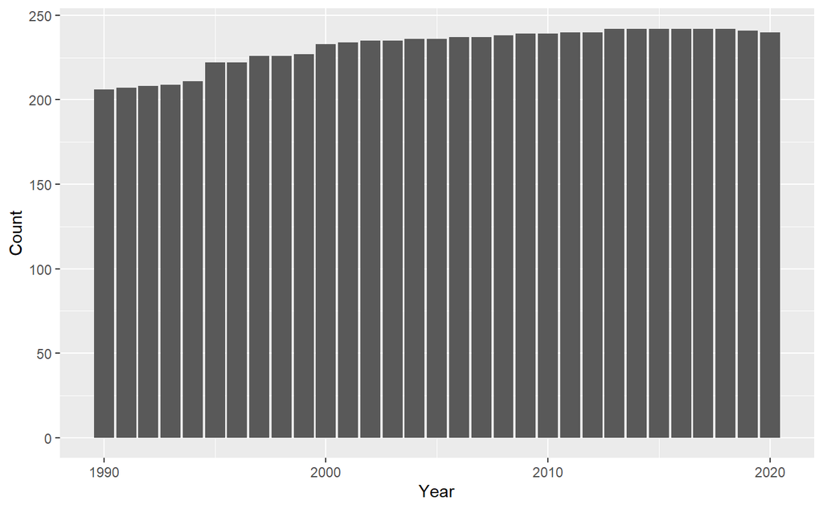

```r
ggplot(countries_per_year, aes(x = Year, y = Count)) + geom_col()
```

4. How many countries are represented in this dataset? Which countries have the fewest observations?

```r
n_distinct(gdp_df$Country)
```

```
[1] 242
```

```r
country_count <- gdp_df |>
  count(Country) |>
  rename(Count = n) |>
  arrange(Count)
country_count |>
  head(2   )
```

| Country | Count |
| --- | --- |
| Djibouti | 8 |
| Somalia | 8 |

5. Create a new dataframe by subsetting gdp_df to just the year 2014. Call this new dataframe gdp_2014.

```r
gdp_2014 <- gdp_df |>
  filter(Year == 2014)
gdp_2014
```

| Country | Year | Value |
| --- | --- | --- |
| Afghanistan | 2014 | 2102.3846 |
| Africa Eastern and Southern | 2014 | 3677.3194 |
| Africa Western and Central | 2014 | 4215.6460 |
| Albania | 2014 | 11586.8339 |
| Algeria | 2014 | 11512.6905 |
| Angola | 2014 | 8240.3480 |
| Antigua and Barbuda | 2014 | 18104.6838 |
| Arab World | 2014 | 13994.6187 |
| Argentina | 2014 | 23550.0991 |
| Armenia | 2014 | 11019.8388 |

[output cut: 232 more lines]

6. Use summary() to find the summary statistics for GDP per capita in 2014.

```r
gdp_2014 |>
  summarize(mean = mean(Value), sum = sum(Value), median = median(Value), min = min(Value), max = max(Value))
```

| mean | sum | median | min | max |
| --- | --- | --- | --- | --- |
| 19612.88 | 4746316 | 12178.87 | 822.6112 | 155201.7 |

7. Create a histogram of GDP Per Capita numbers for 2014 (you may wish to adjust the number of bins for your histogram).

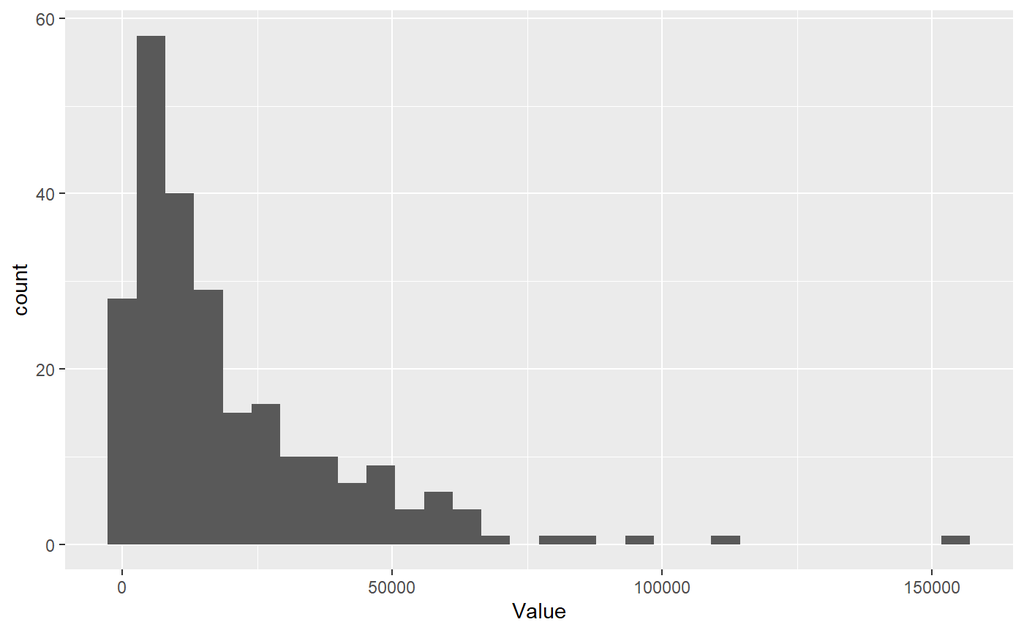

```r
ggplot(gdp_2014, aes(x = Value)) + geom_histogram()
```

8. Find the top 5 counties and bottom 5 countries by GDP per capita in 2014.

```r
gdp_2014 |>
  arrange(desc(Value)) |>
  head(5)
```

| Country | Year | Value |
| --- | --- | --- |
| Macao SAR, China | 2014 | 155201.74 |
| Luxembourg | 2014 | 113313.58 |
| Qatar | 2014 | 95578.26 |
| Singapore | 2014 | 87616.64 |
| Bermuda | 2014 | 77361.10 |

```r
gdp_2014 |>
  arrange(desc(Value)) |>
  tail(5)
```

| Country | Year | Value |
| --- | --- | --- |
| Niger | 2014 | 1126.8054 |
| Dem. Rep. Congo | 2014 | 1029.7908 |
| Somalia | 2014 | 917.8765 |
| Burundi | 2014 | 886.2353 |
| Central African Republic | 2014 | 822.6112 |

9. Now, return to the full dataset, gdp_df. Pivot the data for 1990 and 2018 (using the pandas .pivot_wider() method or another method) so that each row corresponds to a country, each column corresponds to a year, and the values in the table give the GDP_Per_Capita amount. Drop any rows that are missing values for either 1990 or 2018. Save the result to a dataframe named gdp_pivoted.

```r
gdp_pivoted <- gdp_df |>
  filter(Year %in% c(1990, 2018)) |>
  drop_na(Value) |>
  pivot_wider(
    names_from = Year,
    values_from = Value
  )
gdp_pivoted
```

| Country | 2018 | 1990 |
| --- | --- | --- |
| Afghanistan | 2033.8044 | NA |
| Africa Eastern and Southern | 3697.3173 | 3083.9768 |
| Africa Western and Central | 4132.5930 | 2810.3411 |
| Albania | 13317.0923 | 4827.0346 |
| Algeria | 11630.6794 | 8746.3408 |
| Angola | 6982.1294 | 5758.9505 |
| Antigua and Barbuda | 21017.2645 | 15458.6932 |
| Arab World | 14475.8020 | 9711.8480 |
| Argentina | 22747.2417 | 14144.7637 |
| Armenia | 12715.1090 | 5180.0612 |

[output cut: 232 more lines]

10. Create a new column in gdp_pivoted named Percent_Change. This column should contain the percent change in GDP_Per_Capita from 1990 to 2018. Hint: Percent change is calculated as 100*(New Value - Old Value) / Old Value.

```r
gdp_pivoted <- gdp_pivoted |>
  mutate(Percent_Change = 100*(`2018` - `1990`)/`1990`)
gdp_pivoted
```

| Country | 2018 | 1990 | Percent_Change |
| --- | --- | --- | --- |
| Afghanistan | 2033.8044 | NA | NA |
| Africa Eastern and Southern | 3697.3173 | 3083.9768 | 19.8879731 |
| Africa Western and Central | 4132.5930 | 2810.3411 | 47.0495149 |
| Albania | 13317.0923 | 4827.0346 | 175.8855810 |
| Algeria | 11630.6794 | 8746.3408 | 32.9776615 |
| Angola | 6982.1294 | 5758.9505 | 21.2396154 |
| Antigua and Barbuda | 21017.2645 | 15458.6932 | 35.9575753 |
| Arab World | 14475.8020 | 9711.8480 | 49.0530121 |
| Argentina | 22747.2417 | 14144.7637 | 60.8174034 |
| Armenia | 12715.1090 | 5180.0612 | 145.4625236 |

[output cut: 232 more lines]

11. How many countries experienced a negative percent change in GDP per capita from 1990 to 2018?

```r
neg_percent_change <- gdp_pivoted |>
  count(Percent_Change <= 0) |>
  rename(Count = n)
neg_percent_change
```

| Percent_Change <= 0 | Count |
| --- | --- |
| FALSE | 189 |
| TRUE | 17 |
| NA | 36 |

12. Which country had the highest % change in GDP per capita? Create a line plot showing this country’s GDP per capita for all years for which you have data. Put both line charts on the same plot.

```r
gdp_pivoted |>
  arrange(desc(Percent_Change)) |>
  head(2)
```

| Country | 2018 | 1990 | Percent_Change |
| --- | --- | --- | --- |
| Equatorial Guinea | 20386.01 | 1039.985 | 1860.222 |
| China | 15134.00 | 1423.896 | 962.858 |

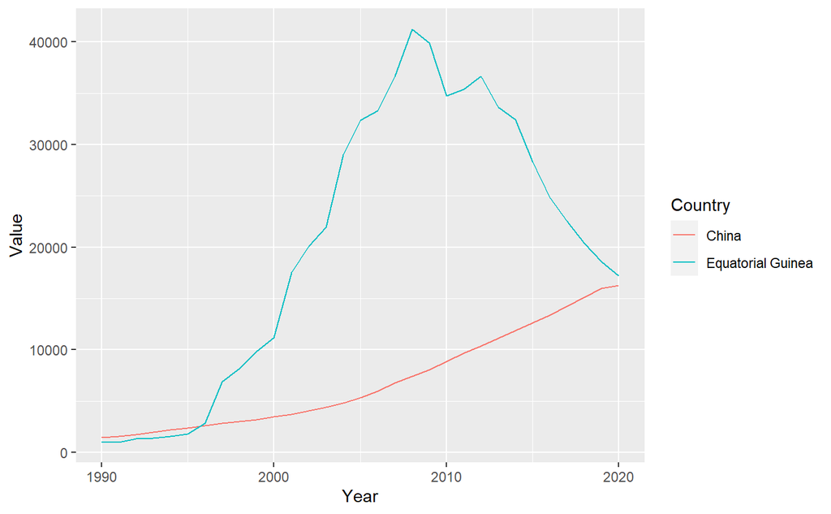

```r
gdp_df |>
  filter(Country %in% c('Equatorial Guinea', 'China')) |>
  ggplot(aes(x = Year, y = Value, color = Country)) +
  geom_line()
```

13. Read in continents.csv contained in the data folder into a new dataframe called continents. We will be using this dataframe to add a new column to our dataset.

```r
continents <- read_csv('../data/continents.csv')
```

14. Merge gdp_df and continents. Keep only the countries that appear in both data frames. Save the result back to gdp_df.

```r
gdp_df <- merge(gdp_df, continents, by="Country")
gdp_df |>
  head(3)
```

|  | Country | Year | Value | Continent |
| --- | --- | --- | --- | --- |
| 1 | Afghanistan | 2015 | 2068.266 | Asia |
| 2 | Afghanistan | 2014 | 2102.385 | Asia |
| 3 | Afghanistan | 2005 | 1286.794 | Asia |

```r
NA
```

15. Determine the number of countries per continent. Create a bar chart showing this.

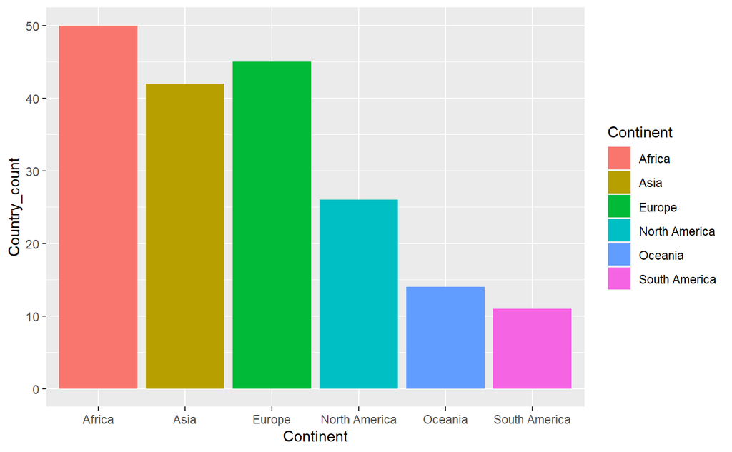

```r
gdp_df |>
  group_by(Continent) |>
  summarize(Country_count = n_distinct(Country)) |>
  ggplot(aes(x = Continent, y = Country_count, fill = Continent)) + geom_col()
```

16. Create a boxplot showing GDP per capita in 2018 split out by continent. What do you notice?

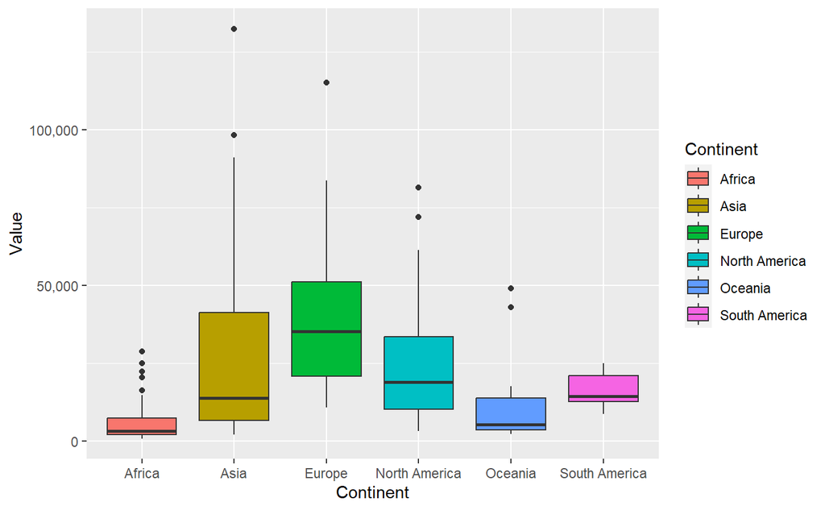

```r
options(scipen = 999)
gdp_df |>
  filter(Year == 2018) |>
  group_by(Continent) |>
  ggplot(aes(x = Continent, y = Value, fill = Continent)) + geom_boxplot() + scale_y_continuous(labels = scales::comma)
```

17. Read life_expectancy.csv into a tibble named life_expectancy. Do not modify the csv file in order to read this data in.

```r
life_expectancy <- read_csv('../data/life_expectancy.csv', skip = 3)
```

```r
life_expectancy
```

| Country Name | Country Code | Indicator Name | Indicator Code | 1960 | 1961 | 1962 | 1963 | 1964 | 1965 | 1966 | 1967 | 1968 | 1969 | 1970 | 1971 | 1972 | 1973 | 1974 | 1975 | 1976 | 1977 | 1978 | 1979 | 1980 | 1981 | 1982 | 1983 | 1984 | 1985 | … |
| --- | --- | --- | --- | --- | --- | --- | --- | --- | --- | --- | --- | --- | --- | --- | --- | --- | --- | --- | --- | --- | --- | --- | --- | --- | --- | --- | --- | --- | --- | --- |
| Aruba | ABW | Life expectancy at birth, total (years) | SP.DYN.LE00.IN | 64.15200 | 64.53700 | 64.75200 | 65.13200 | 65.29400 | 65.50200 | 66.06300 | 66.43900 | 66.75700 | 67.16800 | 67.58300 | 67.97500 | 68.57700 | 69.09200 | 69.50300 | 69.76200 | 70.03500 | 70.26400 | 70.49400 | 70.77800 | 71.06600 | 71.72200 | 71.95900 | 72.10500 | 72.25100 | 72.38800 | … |
| Africa Eastern and Southern | AFE | Life expectancy at birth, total (years) | SP.DYN.LE00.IN | 44.08555 | 44.38670 | 44.75218 | 44.91316 | 45.47904 | 45.49834 | 45.24910 | 45.92491 | 46.22310 | 46.43230 | 46.71848 | 47.19294 | 46.89739 | 47.69232 | 47.59806 | 47.75989 | 48.34959 | 48.63591 | 48.76360 | 49.26134 | 49.63654 | 50.05707 | 50.29685 | 48.70333 | 48.65266 | 49.01163 | … |
| Afghanistan | AFG | Life expectancy at birth, total (years) | SP.DYN.LE00.IN | 32.53500 | 33.06800 | 33.54700 | 34.01600 | 34.49400 | 34.95300 | 35.45300 | 35.92400 | 36.41800 | 36.91000 | 37.41800 | 37.92300 | 38.44400 | 39.00300 | 39.55000 | 40.10000 | 40.64500 | 41.22800 | 40.27100 | 39.08600 | 39.61800 | 40.16400 | 37.76600 | 38.18700 | 33.32900 | 33.55000 | … |
| Africa Western and Central | AFW | Life expectancy at birth, total (years) | SP.DYN.LE00.IN | 37.84515 | 38.16495 | 38.73510 | 39.06372 | 39.33536 | 39.61804 | 39.83783 | 39.47150 | 40.08568 | 40.35042 | 41.03476 | 41.55672 | 42.24979 | 42.85505 | 43.49768 | 44.20125 | 45.00316 | 45.71989 | 46.26954 | 46.67374 | 47.01524 | 47.29719 | 47.52938 | 47.78526 | 47.93192 | 48.02168 | … |
| Angola | AGO | Life expectancy at birth, total (years) | SP.DYN.LE00.IN | 38.21100 | 37.26700 | 37.53900 | 37.82400 | 38.13100 | 38.49500 | 38.75700 | 39.09200 | 39.48400 | 39.82900 | 40.19000 | 40.55400 | 40.90500 | 41.27000 | 41.65200 | 41.19100 | 41.16300 | 41.43700 | 41.83000 | 42.17500 | 42.44900 | 42.77200 | 43.05100 | 42.09200 | 42.35300 | 42.64800 | … |
| Albania | ALB | Life expectancy at birth, total (years) | SP.DYN.LE00.IN | 54.43900 | 55.63400 | 56.67100 | 57.84400 | 58.98300 | 60.01900 | 60.99800 | 61.97200 | 62.94600 | 63.92300 | 64.82400 | 65.61800 | 66.42200 | 67.14000 | 67.76900 | 68.32800 | 68.70400 | 69.12100 | 69.30900 | 69.58400 | 70.47800 | 70.73000 | 71.02300 | 71.29600 | 71.50200 | 71.65600 | … |
| Andorra | AND | Life expectancy at birth, total (years) | SP.DYN.LE00.IN | NA | NA | NA | NA | NA | NA | NA | NA | NA | NA | NA | NA | NA | NA | NA | NA | NA | NA | NA | NA | NA | NA | NA | NA | NA | NA | … |
| Arab World | ARB | Life expectancy at birth, total (years) | SP.DYN.LE00.IN | 44.97290 | 45.67640 | 46.12258 | 46.97247 | 47.89576 | 48.23211 | 48.45707 | 48.91291 | 49.44512 | 49.82224 | 50.35134 | 51.29642 | 51.86446 | 52.53968 | 53.19444 | 53.70986 | 54.04753 | 55.36147 | 56.11217 | 56.82629 | 57.30237 | 57.69293 | 58.05480 | 58.78737 | 59.47898 | 60.21574 | … |
| United Arab Emirates | ARE | Life expectancy at birth, total (years) | SP.DYN.LE00.IN | 48.81100 | 49.69500 | 50.68600 | 51.58400 | 52.84800 | 53.98500 | 55.18500 | 56.33900 | 57.54000 | 58.76000 | 60.02100 | 61.21100 | 62.30400 | 63.35100 | 64.33800 | 65.08000 | 65.82000 | 66.51400 | 67.20900 | 67.84600 | 68.53000 | 69.08500 | 69.66000 | 69.94900 | 70.48500 | 70.74700 | … |
| Argentina | ARG | Life expectancy at birth, total (years) | SP.DYN.LE00.IN | 63.97800 | 64.36000 | 64.24400 | 64.44900 | 64.36300 | 64.59300 | 64.89100 | 64.99200 | 64.89000 | 64.85900 | 65.58900 | 65.54100 | 65.92300 | 66.32300 | 66.56300 | 67.08100 | 67.22800 | 67.86100 | 68.19700 | 68.49100 | 68.56400 | 68.97600 | 68.93700 | 69.26700 | 69.19500 | 69.65100 | … |

[output cut: 256 more lines]

18. Drop the Country Code, Indicator Name, and Indicator Code columns. Then use pivot_longer to convert your data from wide to long. That is, instead of having one row per country and multiple columns per year, we want to have multiple rows per country and a single column for year. After melting, rename the columns to Country, Year, and Life_Expectancy.

```r
life_expectancy <- life_expectancy |>
  select(-c(`Country Code`,`Indicator Name`, `Indicator Code`)) |>
  pivot_longer(cols = -`Country Name`,
               names_to = 'Year',
               values_to = 'Life Expectancy') |>
  rename(Country = `Country Name`)
```

19. What was the first country with a life expectancy to exceed 80?

```r
life_expectancy |>
  filter(`Life Expectancy` > 80) |>
  arrange(Year) |>
  head(1)
```

| Country | Year | Life Expectancy |
| --- | --- | --- |
| Japan | 1996 | 80.21976 |

20. Merge gdp_df and life_expectancy, keeping all countries and years that appear in both DataFrames. Save the result to a new DataFrame named gdp_le. If you get any errors in doing this, read them carefully and correct them. Look at the first five rows of your new data frame to confirm it merged correctly. Also, check the last five rows to make sure the data is clean and as expected.

```r
gdp_le <- merge(gdp_df, life_expectancy, by = c("Country", "Year")) |>
  rename(GDP = Value)
gdp_le |>
  head(5)
```

|  | Country | Year | GDP | Continent | Life Expectancy |
| --- | --- | --- | --- | --- | --- |
| 1 | Afghanistan | 2002 | 1189.785 | Asia | 56.454 |
| 2 | Afghanistan | 2003 | 1235.810 | Asia | 57.344 |
| 3 | Afghanistan | 2004 | 1200.278 | Asia | 57.944 |
| 4 | Afghanistan | 2005 | 1286.794 | Asia | 58.361 |
| 5 | Afghanistan | 2006 | 1315.789 | Asia | 58.684 |

```r
gdp_le |>
  tail(5)
```

|  | Country | Year | GDP | Continent | Life Expectancy |
| --- | --- | --- | --- | --- | --- |
| 5237 | Zimbabwe | 2016 | 2341.305 | Africa | 60.306 |
| 5238 | Zimbabwe | 2017 | 2416.050 | Africa | 60.709 |
| 5239 | Zimbabwe | 2018 | 2497.137 | Africa | 61.414 |
| 5240 | Zimbabwe | 2019 | 2310.635 | Africa | 61.292 |
| 5241 | Zimbabwe | 2020 | 2134.555 | Africa | 61.124 |

21. Create a new DataFrame, named gdp_le_2019 by extracting data for the year 2019 from gdp_le. How many countries have a life expectancy of at least 80 in 2019?

```r
gdp_le_2019 <- gdp_le |>
  filter(Year == 2019)
gdp_le_2019 |>
  filter(`Life Expectancy` >= 80) |>
  nrow()
```

```
[1] 34
```

22. Find the countries that had the top 3 largest GDP per capita figures for 2019. Create a plot showing the change in life expectancy over time for these three countries. This plot should be faceted so that each country is contained in its own figure.

```r
gdp_le_2019 |>
  arrange(desc(GDP)) |>
  head(3)
```

|  | Country | Year | GDP | Continent | Life Expectancy |
| --- | --- | --- | --- | --- | --- |
| 1 | Macao SAR, China | 2019 | 127272.55 | Asia | 84.97800 |
| 2 | Luxembourg | 2019 | 116518.28 | Europe | 82.63902 |
| 3 | Singapore | 2019 | 98283.31 | Asia | 83.59512 |

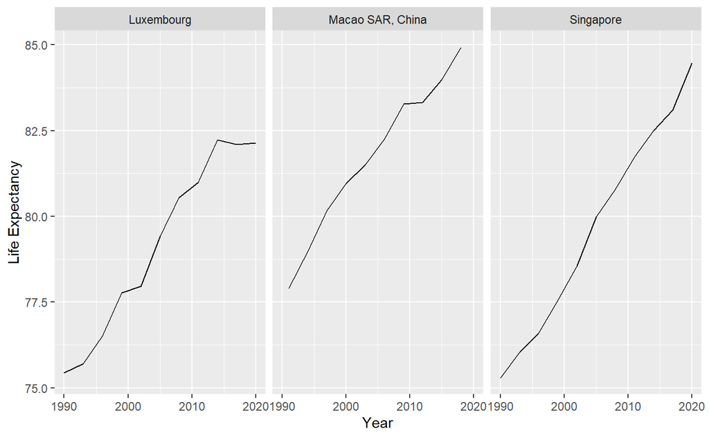

```r
gdp_le |>
  filter(Country == c("Macao SAR, China", "Luxembourg", "Singapore")) |>
  ggplot(aes(x = Year, y = `Life Expectancy`)) + geom_line() + facet_wrap(~Country)
```

23. Create a scatter plot of Life Expectancy vs GDP per Capita for the year 2019. What do you notice?

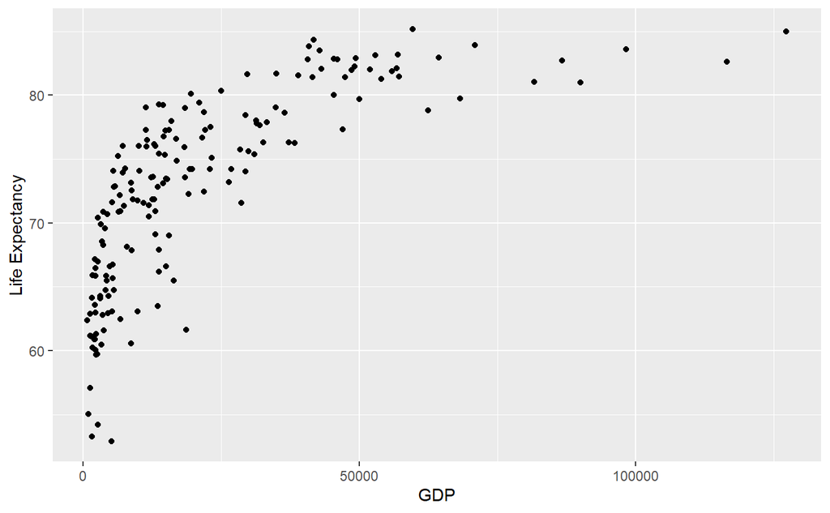

```r
gdp_le_2019 |>
  ggplot(aes(x = GDP, y = `Life Expectancy`)) + geom_point()
```

There seems to be a positive non-linear relationship betwween the two variables.

24. Find the correlation between Life Expectancy and GDP per Capita for the year 2019. What is the meaning of this number?

```r
cor(gdp_le_2019$GDP, gdp_le_2019$`Life Expectancy`)
```

```
[1] NA
```

Result is NA because either column could contain missing values.

```r
cor(gdp_le_2019$GDP, gdp_le_2019$`Life Expectancy`, use = "complete.obs")
```

```
[1] 0.7261468
```

The correlation coefficient shows that there is a strong positive relationship between the two variables.

25. Add a column to gdp_le_2019 and calculate the logarithm of GDP per capita. Find the correlation between the log of GDP per capita and life expectancy. How does this compare to the calculation in the previous part? Look at a scatter plot to see if the result of this calculation makes sense.

```r
gdp_le_2019 <- gdp_le_2019 |>
  mutate(GDP_log = log(GDP))
gdp_le_2019 |>
  head(5)
```

|  | Country | Year | GDP | Continent | Life Expectancy | GDP_log |
| --- | --- | --- | --- | --- | --- | --- |
| 1 | Afghanistan | 2019 | 2065.036 | Asia | 63.565 | 7.632903 |
| 2 | Albania | 2019 | 13653.202 | Europe | 79.282 | 9.521729 |
| 3 | Algeria | 2019 | 11521.984 | Africa | 76.474 | 9.352012 |
| 4 | Angola | 2019 | 6712.022 | Africa | 62.448 | 8.811655 |
| 5 | Antigua and Barbuda | 2019 | 21850.133 | North America | 78.691 | 9.991962 |

```r
cor(gdp_le_2019$GDP_log, gdp_le_2019$`Life Expectancy`, use = "complete.obs")
```

```
[1] 0.8627346
```

There is a stronger positive linear relationship between life expectancy and the logarithmic of GDP per capita in 2019.

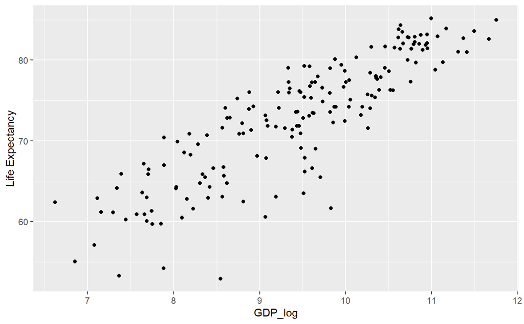

```r
gdp_le_2019 |>
  ggplot(aes(x = GDP_log, y = `Life Expectancy`)) + geom_point()
```